# Assignment 6

Kaeli Mueller

3/1/2021

For my project I made an SQL database through SQL lite. I wanted to make this project relevant to the research that I will be doing for my thesis. However, my project is still very much in the beginning stages and I don’t have all the data gathered for it yet. So what I did was make a database with 3 tables structured the way that I thought would be useful. I will eventually be making some bar graphs from the HANPP_master spreadsheet, and later on I want to do an analysis with variables in each county. That is why I chose State_county to be the primary key.

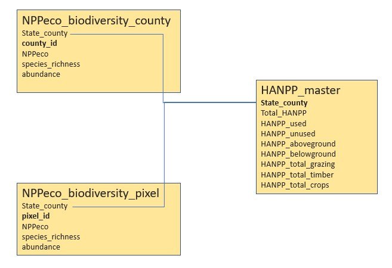

Schema for my database

The packages I need are `RSQLite` and `DBI`

```r
#install.packages("RSQLite")
#prepare libraries
library(DBI)
library(RSQLite)
```

Establish database connection. We can do this once we have constructed a functioning database in SQL. My database is currently empty, but the table structure is all there.

```r
HANPP_db <- dbConnect(drv = RSQLite::SQLite(),
                      "C:/Users/Kaeli/Documents/Computational_Methods/HANPP_database.db")
```

Being able to properly access my database in R has been challenging and R has not yet been successfully able to do it. Full database coming soon…

```r
HANPP_main <- dbGetQuery(conn = HANPP_db, statement = "SELECT * FROM HANPP_master LIMIT 10;")
dbListTables(HANPP_db)

class(HANPP_db)

#Alter database structure
dbExecute(HANPP_db, "DROP TABLE HANPP_main")
```

[output not shown]